# Bibliographic coupling of treatises

```r
suppressPackageStartupMessages(library(tidyverse))
suppressPackageStartupMessages(library(DBI))
suppressPackageStartupMessages(library(dbplyr))
suppressPackageStartupMessages(library(igraph))
suppressPackageStartupMessages(library(tidygraph))
suppressPackageStartupMessages(library(ggraph))
```

The purpose of this notebook is to create preliminary visualizations of how treatises are related to one another. We are going to do this through the concept of bibliographic coupling, which is in effect the inverse of co-citation. Treatises are related to one another if they cite the same cases. This makes a kind of intuitive sense: if a case worth citing is about a discrete contribution to legal knowledge, then treatises that use the same cases are an aggregation of that knowledge.

The database contains a directed network of treatises (identified by their bibliographic identifier, and thus including multiple volumes under a single title). The strength of the connection is determined by the number of cases.

```r
min_cases <- 100
```

We are going to pull the network nodes and edges (limited to edges where there are at least 100 in common) from the database, along with the relevant metadata. Then we will handle the rest in the notebook without the database.

```r
db <- dbConnect(odbc::odbc(), "Research", timeout = 10)
treatises <- tbl(db, in_schema("moml", "us_treatises")) |>
  select(-vols, -subjects, -psmid) |>
  collect()
treatise_subjects <- dbGetQuery(db, "SELECT bibliographicid, unnest(subjects) AS subject FROM moml.us_treatises;") |>
  filter(subject != "US") |>
  collect() |>
  as_tibble()
edges <- tbl(db, in_schema("networks", "treatise_bibliocouple")) |>
  filter(n >= 100) |>
  collect() |>
  mutate(n = as.integer(n))
dbDisconnect(db)
```

We can examine the resulting tables.

```r
treatises |> head()
```

| bibliographicid | year | title |
| --- | --- | --- |
| ocm32192816 | 1796 | An essay on the law of bailments |
| ocm32482886 | 1800 | A system of the law of marine insurances : with three chapters on bottomry, on insurances on lives, and on insurances against fire |
| ocm31140855 | 1800 | A valuable assistant to every man, or, The American clerk's magazine : containing the most useful and necessary forms of writings, which commonly ... |
| ocm31619423 | 1800 | Views of the public debt, receipts & expenditures of the United States |
| ocm31140946 | 1801 | A Friend to the Constitution |
| ocm32419358 | 1801 | A digest of the law of actions and trials at nisi prius |

```r
treatise_subjects |> head()
```

| bibliographicid | subject |
| --- | --- |
| ocm32192816 | Property |
| ocm32192816 | Real Property |
| ocm32482886 | Business Law |
| ocm32482886 | Insurance |
| ocm31140855 | General Studies |
| ocm31619423 | Public Finance |

```r
edges |> head()
```

| t1 | t2 | n |
| --- | --- | --- |
| ocm13490910 | ocm22165649 | 128 |
| ocm17320856 | CTRG97-B3124 | 220 |
| ocm15229653 | CTRG98-B558 | 258 |
| CTRG99-B316 | ocm22165649 | 925 |
| ocm20690162 | ocm22165649 | 432 |
| CTRG98-B558 | CTRG98-B627 | 1352 |

```r
subjects_to_keep <- treatise_subjects |>
  count(subject, sort = TRUE) |>
  filter(!subject %in% c("Administration of Justice and Administrative Law", "General Studies", "Taxation and Public Finance")) |>
  top_n(15)
subjects_to_keep
```

| subject | n |
| --- | --- |
| Procedural Law | 1386 |
| Constitutional Law | 824 |
| Criminal Law | 763 |
| Real Property | 518 |
| Taxation | 449 |
| Administration of Justice | 436 |
| Business Associations | 436 |
| Politics & Government | 426 |
| Commercial Law | 420 |
| Civil Procedure | 383 |

[output cut: 5 more lines]

```r
subject_for_treatises <- subjects_to_keep |>
  select(-n) |>
  left_join(treatise_subjects, by = "subject", multiple = "all") |>
  group_by(bibliographicid) |>
  slice(1)

treatises <- treatises |>
  left_join(subject_for_treatises, by = "bibliographicid")
treatises |> head()
```

| bibliographicid | year | title | subject |
| --- | --- | --- | --- |
| ocm32192816 | 1796 | An essay on the law of bailments | Real Property |
| ocm32482886 | 1800 | A system of the law of marine insurances : with three chapters on bottomry, on insurances on lives, and on insurances against fire | Business Law |
| ocm31140855 | 1800 | A valuable assistant to every man, or, The American clerk's magazine : containing the most useful and necessary forms of writings, which commonly ... | NA |
| ocm31619423 | 1800 | Views of the public debt, receipts & expenditures of the United States | NA |
| ocm31140946 | 1801 | A Friend to the Constitution | Administration of Justice |
| ocm32419358 | 1801 | A digest of the law of actions and trials at nisi prius | Procedural Law |

We want to turn this into a graph object so that we can manipulate it. As it is now, the graph is directed but symmetrical. We want to make it undirected but keep the edge weights (`n`). Here is the resulting object.

```r
# # This is a more complicated way to get to the undirected graph.
# # Preserving it in case the shorter version doesn't work like I expect.
# g1 <- graph_from_data_frame(edges, directed = TRUE, treatises)
# m <- as_adjacency_matrix(g1, attr = "n")
# g2 <- graph_from_adjacency_matrix(m, mode = "upper", weighted = "n", diag = FALSE)
# e <- as_data_frame(g2, "edges")
# g <- graph_from_data_frame(e, directed = FALSE, treatises)
g <- graph_from_data_frame(edges, directed = TRUE, treatises) |>
  as.undirected(mode = "collapse", edge.attr.comb = "max")
g
```

```
IGRAPH 77a8c28 UN-- 10544 236135 --
+ attr: name (v/c), year (v/n), title (v/c), subject (v/c), n (e/n)
+ edges from 77a8c28 (vertex names):
 [1] ocm31530092--ocm31395511 ocm31395511--ocm31396004 ocm31395511--ocm31808830
 [4] ocm31395511--ocm31856634 ocm31372193--ocm31856634 ocm31395511--ocm32367760
 [7] ocm31856634--ocm32367760 ocm31530092--ocm31997696 ocm31395511--ocm31997696
[10] ocm31396004--ocm31997696 ocm31808830--ocm31997696 ocm31856634--ocm31997696
[13] ocm32367760--ocm31997696 ocm31530092--ocm12145335 ocm31395511--ocm12145335
[16] ocm31372193--ocm12145335 ocm31856634--ocm12145335 ocm32367760--ocm12145335
[19] ocm31997696--ocm12145335 ocm12157013--ocm12145335 ocm31395511--ocm29253050
[22] ocm31997696--ocm29253050 ocm12145335--ocm29253050 ocm31530092--ocm31372110
+ ... omitted several edges
```

It can be helpful to understand the distribution of the strength of the edges.

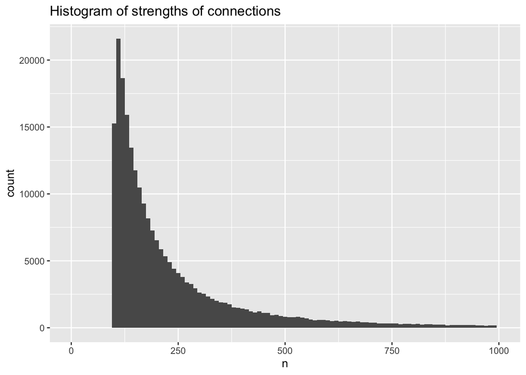

```r
g |>
  as_data_frame("edges") |>
  ggplot(aes(x = n)) +
  geom_histogram(binwidth = 10) +
  xlim(0, 1000) +
  labs(title = "Histogram of strengths of connections")
```

We can now manipulate the graph. Let’s set some parameters.

```r
min_cases2 <- 300
max_year <- 1860
```

We will only keep treatises which have at least one connection, where the connections is at least 300 cases, and where the maximum year for the treatise is 1860.

Here is the result.

```r
tg <- g |>
  as_tbl_graph() |>
  activate(edges) |>
  filter(n >= min_cases2) |>
  activate(nodes) |>
  filter(year < max_year) |>
  filter(centrality_degree() > 0) |>
  mutate(betweenness = centrality_betweenness()) |>
  arrange(desc(betweenness))
tg
```

```
# A tbl_graph: 163 nodes and 961 edges
#
# An undirected simple graph with 17 components
#
# Node Data: 163 × 5 (active)
  name         year title                                   subject     between…
  <chr>       <int> <chr>                                   <chr>          <dbl>
1 ocm31991659  1848 An abridgment of the law of nisi prius… Procedural…    1793.
2 ocm12088490  1858 Commentaries on American law            <NA>           1478.
3 ocm32352245  1851 The American chancery digest : being a… Procedural…     930.
4 ocm15601044  1856 The elements of mercantile law          Commercial…     564.
5 ocm29617630  1847 A treatise on pleading, and parties to… Procedural…     532.
6 ocm31997696  1821 A treatise on the practice of the Supr… Procedural…     454.
# … with 157 more rows
#
# Edge Data: 961 × 3
   from    to     n
  <int> <int> <dbl>
1     6    72   395
2    14    72   382
3     6    14   332
# … with 958 more rows
```

We can now try to plot this.

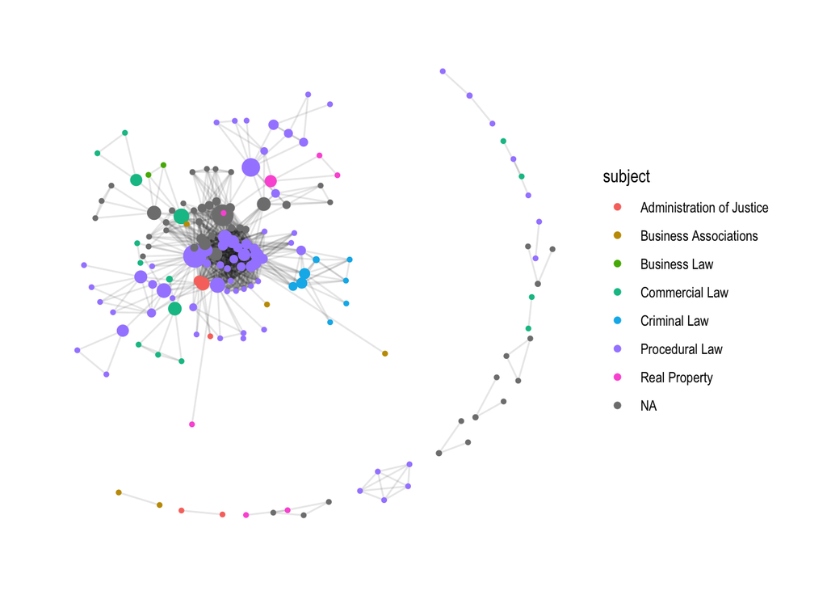

```r
ggraph(tg, layout = "kk") +
  geom_edge_fan(alpha = 0.1) +
  geom_node_point(aes(size = betweenness, color = subject)) +
  guides(size = "none") +
  theme_graph()
```

It may be easier to plot only the biggest subgraph. We can get that subgraph.

```r
g2 <- tg |> as.igraph()
components <- g2 |> clusters(mode = "weak")
biggest_cluster_id <- which.max(components$csize)
vert_ids <- V(g2)[components$membership == biggest_cluster_id]
tg2 <- induced_subgraph(g2, vert_ids) |>
  as_tbl_graph() |>
  arrange(desc(betweenness))
tg2
```

```
# A tbl_graph: 122 nodes and 928 edges
#
# An undirected simple graph with 1 component
#
# Node Data: 122 × 5 (active)
  name         year title                                   subject     between…
  <chr>       <int> <chr>                                   <chr>          <dbl>
1 ocm31991659  1848 An abridgment of the law of nisi prius… Procedural…    1793.
2 ocm12088490  1858 Commentaries on American law            <NA>           1478.
3 ocm32352245  1851 The American chancery digest : being a… Procedural…     930.
4 ocm15601044  1856 The elements of mercantile law          Commercial…     564.
5 ocm29617630  1847 A treatise on pleading, and parties to… Procedural…     532.
6 ocm31997696  1821 A treatise on the practice of the Supr… Procedural…     454.
# … with 116 more rows
#
# Edge Data: 928 × 3
   from    to     n
  <int> <int> <dbl>
1     6    68   395
2    14    68   382
3     6    14   332
# … with 925 more rows
```

The plot it.

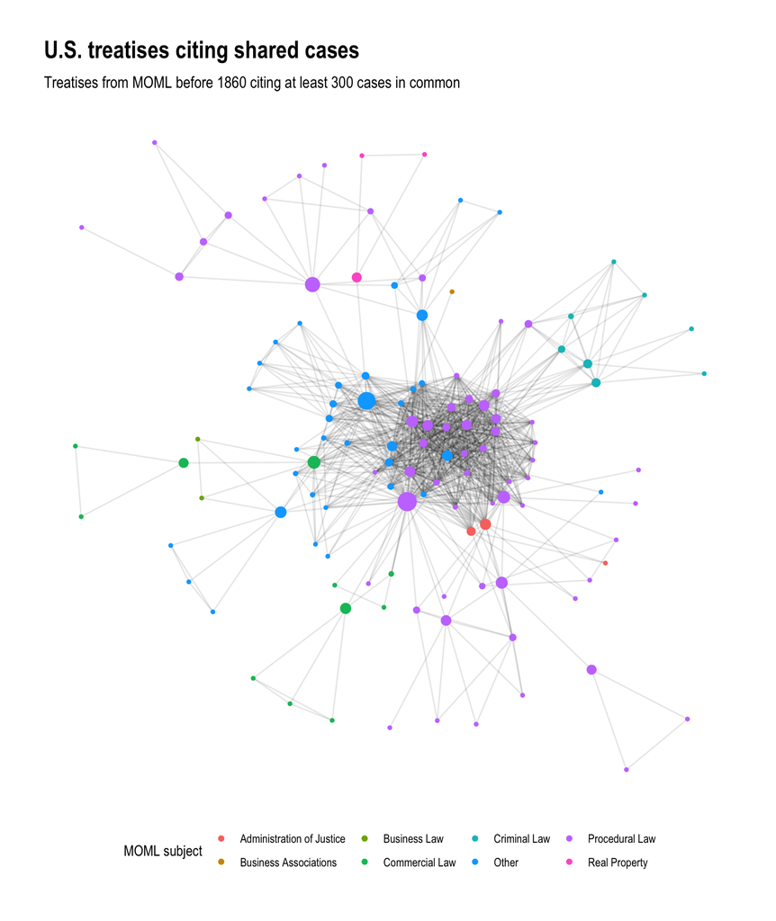

```r
tg2 |>
  mutate(subject = if_else(is.na(subject), "Other", subject)) |>
  ggraph(layout = "kk") +
  geom_edge_fan(alpha = 0.1) +
  geom_node_point(aes(size = betweenness, color = subject)) +
  guides(size = "none") +
  theme_graph() +
  labs(color = "MOML subject", title = "U.S. treatises citing shared cases", subtitle = str_glue("Treatises from MOML before {max_year} citing at least {min_cases2} cases in common")) +
  theme(legend.position = "bottom")
```

So far, so promising.

```r
tg2 |>
  as.data.frame() |>
  arrange(desc(betweenness)) |>
  top_n(10, betweenness) |>
  mutate(title = str_remove(title, ":.+$")) |>
  select(year, title)
```

| year | title |
| --- | --- |
| 1848 | An abridgment of the law of nisi prius |
| 1858 | Commentaries on American law |
| 1851 | The American chancery digest |
| 1856 | The elements of mercantile law |
| 1847 | A treatise on pleading, and parties to actions |
| 1821 | A treatise on the practice of the Supreme Court of New York |
| 1859 | A treatise on maritime law |
| 1854 | The practice in courts of justice in England and the United States |
| 1841 | Digest of the laws of Virginia |
| 1859 | Commentaries on the law of promissory notes, and guaranties of notes, and checks on banks and bankers |